# Exercices Lecture 4

Paolo Crosetto

9/12/2019

# révisons: `left_join()` + tout le reste

## Exercice 1

> en utilisant les jeux de données planes, flights et airports, trouver combien de vols partis de chacun de trois aéroports de NYC a atteri à Denver (DEN) en mai et a été desservi par des avions produits entre 2005 et 2010.

```r
flights %>%
  filter(dest == "DEN") %>%
  filter(month == 5) %>%
  select(tailnum, origin, dest) %>%
  left_join(planes, by = "tailnum") %>%
  filter(year >= 2005 & year <= 2010) %>%
  group_by(origin) %>%
  summarise(reponse = n())
```

```
## # A tibble: 3 x 2
##   origin reponse
##   <chr>    <int>
## 1 EWR         43
## 2 JFK         14
## 3 LGA         48
```

# creating tidy data: reshape with `gather()` and `spread()`

**notes**: `gather()` prend des données au format ‘large’ (plus de colonnes que des lignes) et le reformate au format ‘long’ (plus de lignes que des colonnes). `spread()` est l’opération inverse, qui permet de passer de ‘long’ à ‘large’.

## Exercice 2: `gather()`

> utilisez le jeu de données `table4b` et créez une variable ‘année’ et une variable ‘population’

```r
#1. dire à gather quelles variables recueillir
table4b %>%
  gather(`1999`,`2000`, key = year, value = population)
```

```
## # A tibble: 6 x 3
##   country     year  population
##   <chr>       <chr>      <int>
## 1 Afghanistan 1999    19987071
## 2 Brazil      1999   172006362
## 3 China       1999  1272915272
## 4 Afghanistan 2000    20595360
## 5 Brazil      2000   174504898
## 6 China       2000  1280428583
```

```r
#2. dire à gather les variables qu'on ne veut PAS recueillir
table4b %>%
  gather(-country, key = year, value = population)
```

```
## # A tibble: 6 x 3
##   country     year  population
##   <chr>       <chr>      <int>
## 1 Afghanistan 1999    19987071
## 2 Brazil      1999   172006362
## 3 China       1999  1272915272
## 4 Afghanistan 2000    20595360
## 5 Brazil      2000   174504898
## 6 China       2000  1280428583
```

## Exercice 3: `gather()`

> visualisez et importez dans votre espace de travail les jeux de données `table1` et `table2`. Ils contiennent les mêmes informations. Manipulez `table1` pour obtenir `table2`

```r
table1 <- table1
table2 <- table2

## 1 et 2 strictement équivalents

#1. dire à gather ce qu'on veut recueillir
table1 %>%
  gather(cases, population, key = type, value = count) %>%
  arrange(country, year)
```

```
## # A tibble: 12 x 4
##    country      year type            count
##    <chr>       <int> <chr>           <int>
##  1 Afghanistan  1999 cases             745
##  2 Afghanistan  1999 population   19987071
##  3 Afghanistan  2000 cases            2666
##  4 Afghanistan  2000 population   20595360
##  5 Brazil       1999 cases           37737
##  6 Brazil       1999 population  172006362
##  7 Brazil       2000 cases           80488
##  8 Brazil       2000 population  174504898
##  9 China        1999 cases          212258
## 10 China        1999 population 1272915272
## 11 China        2000 cases          213766
## 12 China        2000 population 1280428583
```

```r
#2. dire à gather ce qu'on ne veut PAS recueilir
table1 %>%
  gather(-country, -year, key = type, value = count)%>%
  arrange(country, year)
```

```
## # A tibble: 12 x 4
##    country      year type            count
##    <chr>       <int> <chr>           <int>
##  1 Afghanistan  1999 cases             745
##  2 Afghanistan  1999 population   19987071
##  3 Afghanistan  2000 cases            2666
##  4 Afghanistan  2000 population   20595360
##  5 Brazil       1999 cases           37737
##  6 Brazil       1999 population  172006362
##  7 Brazil       2000 cases           80488
##  8 Brazil       2000 population  174504898
##  9 China        1999 cases          212258
## 10 China        1999 population 1272915272
## 11 China        2000 cases          213766
## 12 China        2000 population 1280428583
```

## Exercice 4: `gather()`

> reordonnez `world_bank_pop` afin que ‘year’ soit une variable et pour chaque pays et chaque année vous avez deux observations, population urbaine et croissance de la population. Sauvegardez votre résultat dans un objet dans votre workplace.

```r
wbp <- world_bank_pop

wbp %>%
  gather(-country, -indicator, key = year, value = values) -> wbp_long
```

## Exercice 5: `spread()`

> isualisez et importez dans votre espace de travail les jeux de données `table1` et `table2`. Ils contiennent les mêmes informations. Manipulez `table2` pour obtenir `table1`

```r
table2 %>%
  spread(key = type, value = count)
```

```
## # A tibble: 6 x 4
##   country      year  cases population
##   <chr>       <int>  <int>      <int>
## 1 Afghanistan  1999    745   19987071
## 2 Afghanistan  2000   2666   20595360
## 3 Brazil       1999  37737  172006362
## 4 Brazil       2000  80488  174504898
## 5 China        1999 212258 1272915272
## 6 China        2000 213766 1280428583
```

## Exercice 6: `spread()`

> utilisez le jeu de données issu de l’exercice 4. Créez un jeu de données ‘large’ qui montre la croissance de la population urbaine de tous les pays sur les années 2000 et 2001, avec une colonne pour chacune de ces années.

```r
wbp_long %>%
  spread(key = year, value = values) -> wbp_ex6
```

# creating tidy data: `separate()` and `unite()`

## Exercice 7: `separate()`

> utilisez le jeu de données `table3`. séparez la variable ‘rate’ dans les deux variables ‘cases’ et ‘population’

```r
table3 %>%
  separate(rate, into = c("cases", "population"), sep = "/")
```

```
## # A tibble: 6 x 4
##   country      year cases  population
##   <chr>       <int> <chr>  <chr>
## 1 Afghanistan  1999 745    19987071
## 2 Afghanistan  2000 2666   20595360
## 3 Brazil       1999 37737  172006362
## 4 Brazil       2000 80488  174504898
## 5 China        1999 212258 1272915272
## 6 China        2000 213766 1280428583
```

## Exercice 8: `separate()`

> utilisez `world_bank_pop` et créez une variable qui vous permette de distinguer entre indicateurs ‘pop’ and ‘urban’ et une autre pour distinguer enre indicateurs de ‘total’ and ‘growth’.

```r
wbp %>%
  separate(indicator, into = c("poubelle", "urb_pop", "tot_grow")) %>%
  select(-poubelle)
```

```
## # A tibble: 1,056 x 21
##    country urb_pop tot_grow `2000` `2001` `2002` `2003`  `2004`  `2005`
##    <chr>   <chr>   <chr>     <dbl>  <dbl>  <dbl>  <dbl>   <dbl>   <dbl>
##  1 ABW     URB     TOTL     4.24e4 4.30e4 4.37e4 4.42e4 4.47e+4 4.49e+4
##  2 ABW     URB     GROW     1.18e0 1.41e0 1.43e0 1.31e0 9.51e-1 4.91e-1
##  3 ABW     POP     TOTL     9.09e4 9.29e4 9.50e4 9.70e4 9.87e+4 1.00e+5
##  4 ABW     POP     GROW     2.06e0 2.23e0 2.23e0 2.11e0 1.76e+0 1.30e+0
##  5 AFG     URB     TOTL     4.44e6 4.65e6 4.89e6 5.16e6 5.43e+6 5.69e+6
##  6 AFG     URB     GROW     3.91e0 4.66e0 5.13e0 5.23e0 5.12e+0 4.77e+0
##  7 AFG     POP     TOTL     2.01e7 2.10e7 2.20e7 2.31e7 2.41e+7 2.51e+7
##  8 AFG     POP     GROW     3.49e0 4.25e0 4.72e0 4.82e0 4.47e+0 3.87e+0
##  9 AGO     URB     TOTL     8.23e6 8.71e6 9.22e6 9.77e6 1.03e+7 1.09e+7
## 10 AGO     URB     GROW     5.44e0 5.59e0 5.70e0 5.76e0 5.75e+0 5.69e+0
## # … with 1,046 more rows, and 12 more variables: `2006` <dbl>,
## #   `2007` <dbl>, `2008` <dbl>, `2009` <dbl>, `2010` <dbl>, `2011` <dbl>,
## #   `2012` <dbl>, `2013` <dbl>, `2014` <dbl>, `2015` <dbl>, `2016` <dbl>,
## #   `2017` <dbl>
```

## Exercice 9: `unite()`

> utilisez le jeu de données `table5` et mergez dans une seule variable ‘année’ les colones ‘century’ et ‘year’

```r
table5 %>%
  unite("anee", century, year, sep = "")
```

```
## # A tibble: 6 x 3
##   country     anee  rate
##   <chr>       <chr> <chr>
## 1 Afghanistan 1999  745/19987071
## 2 Afghanistan 2000  2666/20595360
## 3 Brazil      1999  37737/172006362
## 4 Brazil      2000  80488/174504898
## 5 China       1999  212258/1272915272
## 6 China       2000  213766/1280428583
```

## Exercice 10: `unite()`

> utilisez le jeu de données `flights` et créez une variable unique ‘date’ pour jour, mois et année

```r
flights %>%
  unite("date", day, month, year, sep = ".")
```

```
## # A tibble: 336,776 x 17
##    date  dep_time sched_dep_time dep_delay arr_time sched_arr_time
##    <chr>    <int>          <int>     <dbl>    <int>          <int>
##  1 1.1.…      517            515         2      830            819
##  2 1.1.…      533            529         4      850            830
##  3 1.1.…      542            540         2      923            850
##  4 1.1.…      544            545        -1     1004           1022
##  5 1.1.…      554            600        -6      812            837
##  6 1.1.…      554            558        -4      740            728
##  7 1.1.…      555            600        -5      913            854
##  8 1.1.…      557            600        -3      709            723
##  9 1.1.…      557            600        -3      838            846
## 10 1.1.…      558            600        -2      753            745
## # … with 336,766 more rows, and 11 more variables: arr_delay <dbl>,
## #   carrier <chr>, flight <int>, tailnum <chr>, origin <chr>, dest <chr>,
## #   air_time <dbl>, distance <dbl>, hour <dbl>, minute <dbl>,
## #   time_hour <dttm>
```

# récapitulons le tout: babynames

On va ici utiliser le jeu de données `babynames` (dans le package `babynames`).

1. installez le package `babynames`
2. regardez les données. Cela contient quoi?
3. on va faire quelaues exercices.

## babynames ex1: ‘Mary’ (`filter` + `ggplot`)

> plottez (geom_line) le nombre de Mary aux EE.UU. sur toute la longueur des données.

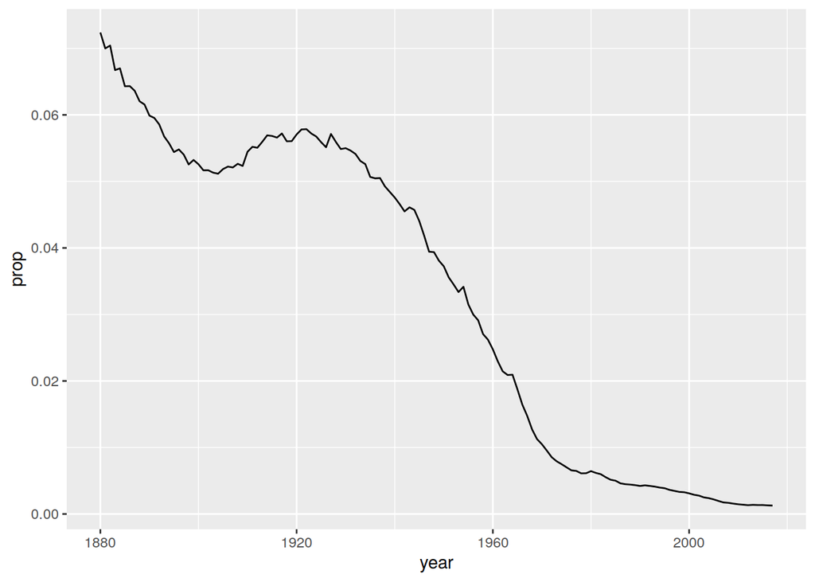

```r
library(babynames)

df <- babynames

df %>%
  filter(name == "Mary") %>%
  filter(sex == "F") %>%
  ggplot(aes(x = year, y = prop))+geom_line()
```

## babynames ex2: ‘Mary vs. ’Anna’ (`filter` + `ggplot`)

> plottez (geom_line) le nombre de Mary et de Anna aux EE.UU. sur toute la longueur des données. Quand est-ce que Anna est devenue plus populaire que Mary (si jamais)? COloriez différemment les lignes pour Anna et Mary

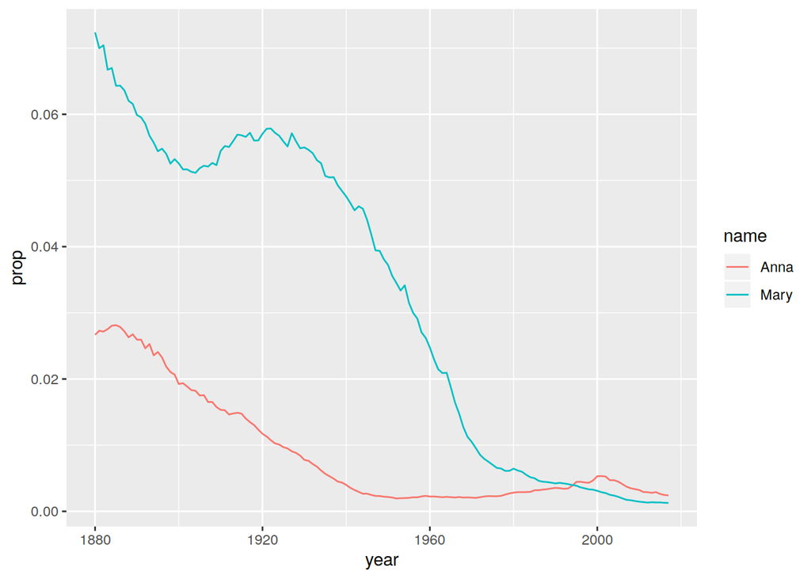

```r
df %>%
  filter(name == "Mary" | name == "Anna") %>%
  filter(sex == "F") %>%
  ggplot(aes(x = year, y = prop, color = name))+
  geom_line()
```

## babynames ex3: prénoms de garçons

> isolez le prénom le plus populaire pour les garçons pour chaque année. Quel nom était le plus utilisé en 1890? et en 1990?

```r
df %>%
  filter(sex == "M") %>%
  group_by(year) %>%
  filter(n == max(n)) %>%
  filter(year == 1890 | year == 1990)
```

```
## # A tibble: 2 x 5
## # Groups:   year [2]
##    year sex   name        n   prop
##   <dbl> <chr> <chr>   <int>  <dbl>
## 1  1890 M     John     8502 0.0710
## 2  1990 M     Michael 65282 0.0303
```

## babynames ex4: dispersion des prénoms

> est-ce que les prénoms étaient plus concentrés dans le passé (moins de noms, plus de gens pour chaque nom) qu’aujours’hui? Calculez le nombre de noms, séparément pour hommes et femmes, par année. Plottez les résultats comme une geom_line, colorié par sexe. Est-ce que le nombre de noms augmente ou diminue? plus pour les filles ou pour les garçons?

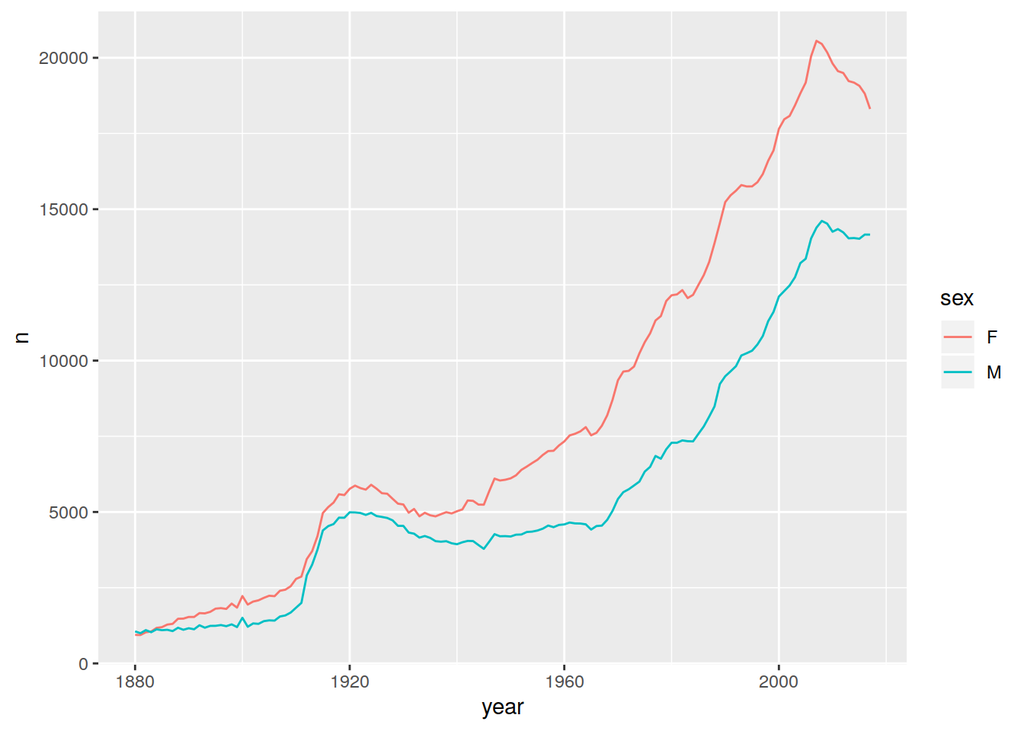

```r
df %>%
  group_by(year, sex) %>%
  summarise(n = n()) %>%
  ggplot(aes(x = year, y = n, color = sex))+
  geom_line()
```

## babynames ex5: tab prénom populaires

> créez un tableau avec le prénom le plus populaire (en valeur absolue) pour chaque **décennie** du 20ème siècle, pour les filles et les garçons. Faites un tableau ‘large’ avec comme variable ‘décennie’, ‘M’ et ‘F’

```r
df %>%
  mutate(decade = (year %/% 10)*10) %>%
  group_by(decade, sex) %>%
  filter(n == max(n)) %>%
  select(decade, sex, name) -> temp

temp %>%
  spread(key = sex, value = name) -> reponse
```

## babynames ex6: ggplot

> créez un plot qui montre, dans un facet (subplot) pour chaque prénom (lignes) et par sèxe (colonnes), le profil au cours du temps des prénoms suivants: “Mary” “John” “Robert” “James” “Linda” “Michael” “David” “Lisa” “Jennifer” “Jessica” “Ashley” “Emily” “Jacob” “Emma” “Isabella” “Sophia” “Noah” “Liam”

```r
df %>%
  filter(name %in% c("Mary", "John",   "Robert",  "James",    "Linda",    "Michael",  "David",    "Lisa",     "Jennifer", "Jessica",  "Ashley",   "Emily",    "Jacob",    "Emma", "Isabella", "Sophia",   "Noah",     "Liam")) %>%
  group_by(year, name) %>%
  arrange(year, name, -prop) %>%
  mutate(i = seq_along(prop)) %>%
  filter(i == 1) %>%
  ggplot(aes(x = year, y = prop, color = name))+
  geom_line()+
  facet_grid(name~sex, scale = "free") -> plot
```